# Multivariate Random Regression

`randomRegress()` and `plot_randomRegress()`

Author

Julian Taylor

Published

October 9, 2026

[figure not shown]

## Overview

Although the `randomRegress()` function has been set up generally, to aid in intepretation this vignette focusses on specific use cases that allow a decomposition a multivariate set of variety BLUPs into two interpretable components:

- **Baseline** — a variety’s genetic value at the reference level, returned with the prefix `base.`
- **Adjusted** — the part of a variety’s genetic value at a given level that is *not* linearly predictable from the levels it is conditioned on, returned with the prefix `adj.`

The decomposition is derived from the **G-matrix** (the genetic variance–covariance matrix across the levels being decomposed) using Gaussian conditional distribution theory. It generalises naturally from two levels to any number, with four built-in conditioning schemes.

### Scope

The dimension that is **decomposed** holds multiple **treatments** or multiple **traits** that are applied to, or measured on, the same plants within the one experiment. This is what makes a genetic regression between them meaningful. The levels are commensurable, so the conditional distribution of one given another has a genuine biological interpretation. They are:

- **Treatments**: the baseline can be viewed as the variety’s **efficiency**, its genetic value under the control or low-input treatment. The adjusted component is its **responsiveness** (or **tolerance**), the extra genetic gain it realises when the treatment is applied.
- **Traits**: the baseline is just the unadjusted variety genetic value for the trait and the adjusted component is part of the genetic value of the second trait that is not genetically predictable from another.

The second dimension is the **section**, ordinarily the site or environment. The decomposition is simply repeated, independently, within each section. There may be one section or many:

| Grouping factor | Decomposed (`levs`) | Sections | Use case |
| --- | --- | --- | --- |
| `us(Treatment)` — plain | treatments | one, `"Single"` | Multi-treatment, single site |
| `us(Trait)` — plain | traits | one, `"Single"` | Multivariate (multi-trait), single site |
| `us(TSite)` — composite | treatments | sites | Multi-treatment MET |
| `us(TraitSite)` — composite | traits | sites | Multi-trait MET |

Where the grouping factor is a composite of two factors, such as the Treatment-by-Site factor `TSite` used throughout this vignette, the decomposition is carried out independently within each level of the second factor. Where it is a plain factor there is a single section, reported as `"Single"`, and plots show one facet column.

The section label is returned in the `Section` column of `res$blups`, whatever the repeated-over dimension represents, and the variety BLUPs are keyed by a column named after the unit factor itself — `Variety` for a term of `us(TSite):Variety`, `Genotype` for `us(TSite):Genotype`. Both names are also returned, in `res$section` and `res$unit`.

`plot_randomRegress()` visualises the result as a regression scatter plot, a baseline–adjusted quadrant plot, or a G-matrix heatmap.

To motivate the mathematical framework and illustrate the use of the function, multi-treatment MET data is used because it represents one of the most complex cases, exercising both dimensions at once; the single-section cases follow by simply supplying a plain grouping factor.

## Mathematical Framework

### The G-matrix

For full specification of the multi-treatment, multi-environment LMM used in this vignette see the Simulating Multi-Environment Trials vignette. This vignette specifically discusses partitioning of $\tilde{\mathbf{u}}$, a vector of variety BLUPs from the fitted multi-treatment, multi-environment LMM that are stacked across all $p = T \times S$ groups, where $T$ is the number of treatments and $S$ the number of sites. For ease of notation we have removed the use of tilde throughout the remainder of this mathematical framework. Let the genetic variance–covariance structure of these BLUPs be described by the **G-matrix**:

$$\operatorname{Var}(\mathbf{u}) = \mathbf{G} \otimes \mathbf{I}_n,$$

where $\mathbf{I}_n$ is the $n \times n$ identity over varieties and the $p \times p$ G-matrix has a natural $S \times S$ block structure, with each block being $T \times T$:

$$\mathbf{G} =
\begin{pmatrix}
\mathbf{G}_{11} & \mathbf{G}_{12} & \cdots & \mathbf{G}_{1S} \\
\mathbf{G}_{21} & \mathbf{G}_{22} & \cdots & \mathbf{G}_{2S} \\
\vdots & \vdots & \ddots & \vdots \\
\mathbf{G}_{S1} & \mathbf{G}_{S2} & \cdots & \mathbf{G}_{SS}
\end{pmatrix}.$$

Each **diagonal block** $\mathbf{G}_{ss}$ is the $T \times T$ matrix of genetic (co)variances among treatments *within* site $s$:

$$\mathbf{G}_{ss} =
\begin{pmatrix}
\sigma^2_{1s} & \sigma_{1s,2s} & \cdots & \sigma_{1s,Ts} \\
\sigma_{2s,1s} & \sigma^2_{2s} & \cdots & \sigma_{2s,Ts} \\
\vdots & \vdots & \ddots & \vdots \\
\sigma_{Ts,1s} & \sigma_{Ts,2s} & \cdots & \sigma^2_{Ts}
\end{pmatrix},$$

where $\sigma^2_{ts}$ is the genetic variance for treatment $t$ at site $s$ and $\sigma_{ts,t's}$ is the genetic covariance between treatments $t$ and $t'$ within the same site. Each **off-diagonal block** $\mathbf{G}_{ss'}$ ($s \neq s'$) is the analogous $T \times T$ matrix of genetic covariances for treatment pairs *across* sites $s$ and $s'$.

### Allowable ASReml-R specifications

ASReml-R allows various specifications of the Treatment $\times$ Site $\times$ Variety interaction. Once a model is fitted the `term` argument in `randomRegress()` can used to specify the Treatment $\times$ Site $\times$ Variety interaction term. Supported ASReml-R covariance/correlation structures are:

| Description | Structure functions |
| --- | --- |
| Site relationships | `fa()`, `us()`, `corgh()`, `corh()`, `diag()` |
| Variety relationships | `id()`, `ide()`, `vm()` |

For ASReml-R models that used `corgh()` and `corh()`, `randomRegress()` will extract the estimated matrix and convert it to a fully unstructured variance matrix $\mathbf{G}$ before genetic regression calculations are undertaken.

### Example `term` strings

```r
randomRegress(model, term = "fa(Site, 2):id(Variety)", ...)
randomRegress(model, term = "fa(Site, 1):vm(Variety, K)", ...)
randomRegress(model, term = "corgh(Site):id(Variety)", ...)
randomRegress(model, term = "us(Site):vm(Variety, K)", ...)
randomRegress(model, term = "corh(Site):Variety", ...)
```

### Two treatments

To motivate the general case, consider a single site with two treatments where the within-site variance-covariance structure is

$$\mathbf{G}_{ss} =
\begin{pmatrix} G_{11} & G_{12} \\ G_{12} & G_{22} \end{pmatrix},$$

so the variety BLUPs $u_1$ and $u_2$ under the two treatments are jointly normal with mean zero and variance $\mathbf{G}_{ss}$. Conditioning treatment 2 on treatment 1 gives

$$u_2 \mid u_1 \sim \mathcal{N}\!\left(\beta\, u_1,\; \sigma^2_{2 \mid 1}\right),
\qquad
\beta = G_{12}/G_{11},
\qquad
\sigma^2_{2 \mid 1} = G_{22}\left(1 - \rho^2\right),$$

where $\rho = G_{12} / \sqrt{G_{11}G_{22}}$ is the genetic correlation between the two treatments. Here $u_1$ is the **baseline** BLUP and the residual $r_2 = u_2 - \beta u_1$ is the **adjusted** BLUP.

The form $G_{22}(1 - \rho^2)$ shows exactly what adjusted measures i.e. the genetic variance in treatment 2 that its correlation with treatment 1 leaves unexplained. As $\rho \to 1$ the adjusted variance vanishes and then treatment 2 tells us nothing that treatment 1 has not already explained, and there is no independent axis on which to select. When $\rho$ is moderate, a substantial share of the genetic variance in treatment 2 is unique to it, and baseline and adjusted can be selected on separately.

### Universal conditional decomposition

At ths point it is prudent to note that conditioning is performed **within sites only**. For a given site $s$, the $T$ treatment groups are indexed locally as $j = 1, \ldots, T$. The scalar $G_{jj}$ is the marginal genetic variance for treatment $j$ at site $s$, i.e. the $(j,j)$ element of the within-site diagonal block $\mathbf{G}_{ss}$. The sub-vector $\mathbf{G}_{A_j j}$ contains the covariances between treatment $j$ and the conditioning set $A_j \subseteq \{1,\ldots,T\} \setminus \{j\}$, drawn from the same block $\mathbf{G}_{ss}$.

With this specification the **multivariate conditional normal** distribution gives the regression of $u_{j}$ on $\mathbf{u}_{A_j}$:

$$u_{j} \mid \mathbf{u}_{A_j}
\sim \mathcal{N}\!\left(
\boldsymbol{\beta}_j^\top \mathbf{u}_{A_j},\;
\sigma^2_{j \mid A_j}
\right),$$

where the **regression coefficients** and **conditional genetic variance** are

$$\boldsymbol{\beta}_j = \mathbf{G}_{A_j A_j}^{-1}\, \mathbf{G}_{A_j j},
\qquad
\sigma^2_{j \mid A_j} = G_{jj} - \mathbf{G}_{j A_j}\,\boldsymbol{\beta}_j.$$

Here $\mathbf{G}_{A_j A_j}$, $\mathbf{G}_{A_j j}$, and $G_{jj}$ are all sub-blocks or elements of the within-site diagonal block $\mathbf{G}_{ss}$.

The **adjusted BLUP** for variety $v$ is the residual from this regression:

$$r_{j,v} = u_{j,v} - \boldsymbol{\beta}_j^\top \mathbf{u}_{A_j,v}.$$

Adjusted BLUPs are:

- **zero-mean** within each treatment-site group (inherited from the BLUPs)
- **orthogonal** to the conditioning BLUPs in the G-matrix sense
- **genetically independent** of the baseline signal, with variance $\sigma^2_{j \mid A_j}$

The orthogonality property follows directly from the definition of $\boldsymbol{\beta}_j$. For any conditioning treatment $l \in A_j$,

$$\operatorname{Cov}(u_l,\, r_j)
= G_{lj} - \mathbf{G}_{l A_j}\,\boldsymbol{\beta}_j
= G_{lj} - \mathbf{G}_{l A_j}\,\mathbf{G}_{A_j A_j}^{-1}\,\mathbf{G}_{A_j j}
= 0 .$$

The final step holds because $l$ is itself a member of $A_j$, so the row vector $\mathbf{G}_{l A_j}$ is a row of $\mathbf{G}_{A_j A_j}$ and the product $\mathbf{G}_{l A_j}\mathbf{G}_{A_j A_j}^{-1}$ is the corresponding unit vector, leaving $G_{lj} - G_{lj} = 0$.

### The transformation matrix

Collecting all conditioning relationships defines a sparse transformation matrix $\mathbf{T}$ such that:

$$\mathbf{u}^{*} = \mathbf{T}\mathbf{u},
\qquad
\operatorname{Var}(\mathbf{u}^{*}) = \mathbf{T}\mathbf{G}\mathbf{T}^\top
\equiv \mathbf{V}_T.$$

Because conditioning is within sites, $\mathbf{T}$ is block-diagonal with one $T \times T$ block $\mathbf{T}_s$ per site, and the entries of $\mathbf{T}_s$ contain the regression coefficients. In general $\mathbf{T}_s$ has this form

$$[\mathbf{T}_s]_{jl} =
\begin{cases}
1 & l = j \\
-\beta_{jl} & l \in A_j \\
0 & \text{otherwise,}
\end{cases}$$

where $\beta_{jl}$ denotes the element of $\boldsymbol{\beta}_j$ corresponding to conditioning treatment $l$. Each row of $\mathbf{T}_s$ therefore says “take treatment $j$ and subtract off what its conditioning set predicts”. Rows for unconditional treatments are left as unit vectors.

The transformed within-site block is then

$$\mathbf{V}_{T,s} \equiv \mathbf{T}_s\,\mathbf{G}_{ss}\,\mathbf{T}_s^\top ,$$

and $\mathbf{V}_T$ carries these blocks down its diagonal, one per site. The diagonal entries of $\mathbf{V}_{T,s}$ are the conditional genetic variances $\sigma^2_{j \mid A_j}$, while its off-diagonal entries record any remaining covariance between the transformed components.

### Conditioning schemes

The function allows complete flexibility in the choice of conditioning schemes. To help users there are four built-in schemes and they only differ in the conditioning set $A_j$. To to help understand the differences in the transformation components of these onditioning schemes consider $T = 3$ at a single site. Treatments are indexed in the order supplied to the `levs` argument of the function, so treatment 1 is the baseline and column $\bullet$ in the $\mathbf{V}_{T,s}$ marks an entry that is generally non-zero.

| Scheme | $A_j$ | $\mathbf{T}_s$ | $\mathbf{V}_{T,s}$ | Best for |
| --- | --- | --- | --- | --- |
| `"baseline"` | $\{1\}$, $j > 1$ | $\begin{pmatrix} 1 & 0 & 0 \\ -\beta_{21} & 1 & 0 \\ -\beta_{31} & 0 & 1 \end{pmatrix}$ | $\begin{pmatrix} \bullet & 0 & 0 \\ 0 & \bullet & \bullet \\ 0 & \bullet & \bullet \end{pmatrix}$ | Comparing all treatments with one reference treatment |
| `"sequential"` | $\{1, \ldots, j-1\}$ | $\begin{pmatrix} 1 & 0 & 0 \\ -\beta_{21} & 1 & 0 \\ -\beta_{31} & -\beta_{32} & 1 \end{pmatrix}$ | $\begin{pmatrix} \bullet & 0 & 0 \\ 0 & \bullet & 0 \\ 0 & 0 & \bullet \end{pmatrix}$ | Fully orthogonal components |
| `"partial"` | $\{1,2,3\} \setminus \{j\}$ | $\begin{pmatrix} 1 & -\beta_{12} & -\beta_{13} \\ -\beta_{21} & 1 & -\beta_{23} \\ -\beta_{31} & -\beta_{32} & 1 \end{pmatrix}$ | $\begin{pmatrix} \bullet & \bullet & \bullet \\ \bullet & \bullet & \bullet \\ \bullet & \bullet & \bullet \end{pmatrix}$ | Partial genetic variances; no natural baseline |
| `"custom"` | User-specified | e.g. $\begin{pmatrix} 1 & 0 & 0 \\ -\beta_{21} & 1 & 0 \\ 0 & -\beta_{32} & 1 \end{pmatrix}$ | Depends | Bespoke experimental logic |

The first three built-in patterns nest. `type = "baseline"` fills the first column, `type = "sequential"` extends this to the whole strict lower triangle, and `type = "partial"` fills every off-diagonal entry. Each step conditions on more information, so the conditional variances on the diagonal of $\mathbf{V}_{T,s}$ will accordingly.

Under `type = "sequential"` the matrix $\mathbf{T}_s$ is unit lower-triangular and equal to $\mathbf{L}_s^{-1}$, where $\mathbf{G}_{ss} = \mathbf{L}_s\mathbf{D}_s\mathbf{L}_s^\top$ is the Cholesky decomposition of the within-site block. Hence $\mathbf{V}_{T,s} = \mathbf{D}_s$ exactly where all $T$ components are mutually orthogonal, a complete Gram-Schmidt orthogonalisation of the BLUP space.

## Example 1 — Single site, partial conditioning

> **Requires:** ASReml-R V4. The vignette is pre-rendered so no licence is needed to read it; run the code chunks only if you have both packages installed.

### Simulated data

We simulate a single-site trial with 50 varieties and three nitrogen treatments (T0 = control, T1 = low N, T2 = high N), three replicates per treatment. With only one site, the G-matrix is a $3 \times 3$ matrix describing the genetic (co)variances between treatments.

We use `sim.options` to restrict the auto-generated between-treatment genetic correlations to a moderate range (0.55–0.70). This keeps the true genetic structure well away from the parameter boundary, giving the `corgh` model a stable likelihood surface to optimise. The default `sigma_genetic` and `error_sd` values produce a per-plot heritability of approximately 0.60, an ample signal for reliable estimation with 50 varieties and 3 replicates.

```r
out1 <- simTrialData(
  nvar       = 50L,
  nsite      = 1L,
  treatments = c("T0", "T1", "T2"),
  nrep       = 3L,
  seed       = 7L,
  verbose    = FALSE,
  sim.options = list(g_cor_min = 0.55, g_cor_max = 0.70)
)
dat1 <- out1$data
```

The field layout can be examined with `plot_simTrialData()`:

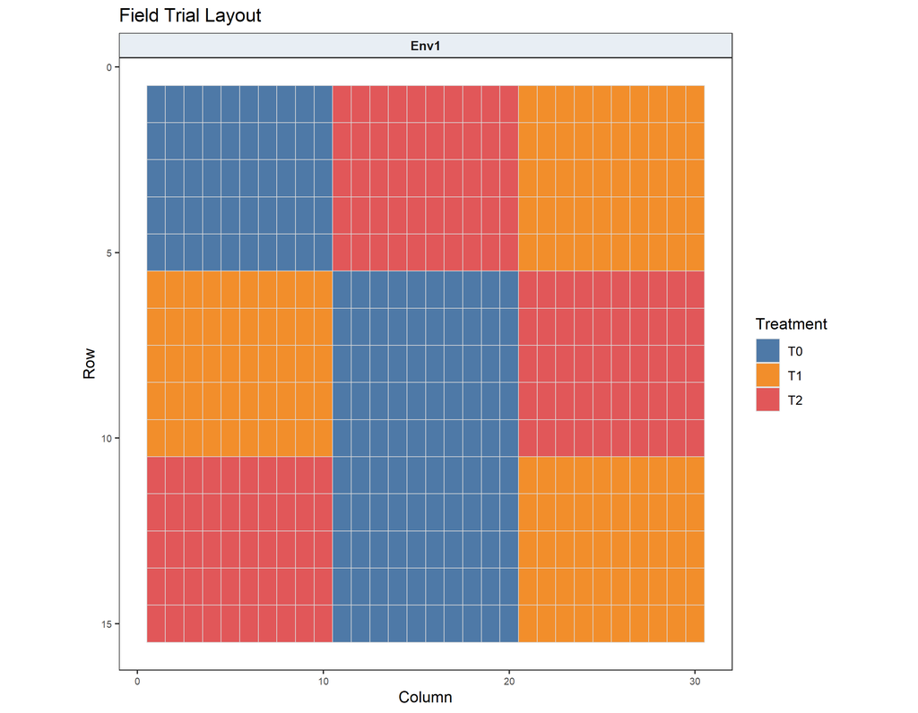

```r
plot_simTrialData(out1, type = "trial", fill = "Treatment", ncol = 3L)
```

### Forming `TSite` and fitting the model

```r
dat1$TSite  <- interaction(dat1$Treatment, dat1$Site, sep = "-")
dat1$Row    <- factor(dat1$Row)
dat1$Column <- factor(dat1$Column)
levs1       <- c("T0", "T1", "T2")
```

We fit a **heterogeneous-correlation** (`corgh`) model. With three treatments this parameterises the $3 \times 3$ G-matrix with three genetic variances and three pairwise correlations — the most flexible fully-identified structure for this problem size:

```r
model1 <- asreml(
  yield    ~ TSite,
  random   = ~ corgh(TSite):Variety + at(Site):Rep,
  residual = ~ ar1(Row):ar1(Column),
  data     = dat1,
  maxit    = 30L
)
model1 <- update(model1)
```

```r
vc1 <- summary(model1)$varcomp
vc1[grepl("TSite", rownames(vc1)), 1:2]
```

```
                                                  component    std.error
TSite:Variety!TSite!T1-Env1:!TSite!T0-Env1.cor 8.266140e-01 2.075354e-01
TSite:Variety!TSite!T2-Env1:!TSite!T0-Env1.cor 6.284402e-01 3.756896e-01
TSite:Variety!TSite!T2-Env1:!TSite!T1-Env1.cor 6.492141e-01 3.901779e-01
TSite:Variety!TSite_T0-Env1                    5.714666e+04 2.127251e+04
TSite:Variety!TSite_T1-Env1                    4.931515e+04 1.969887e+04
TSite:Variety!TSite_T2-Env1                    1.651471e+04 1.323835e+04
```

The `corgh` varcomp rows give the genetic variance for each `TSite` level (diagonal of the G-matrix) and the estimated genetic correlation between each pair. With true correlations in the range 0.55–0.70 and 50 varieties across 3 replicates, the estimates should be well away from the boundary ($|r| \ll 1$), ensuring the reconstructed G-matrix is positive definite and all conditional variances are positive.

### Running `randomRegress()` — partial conditioning

With a single site, **partial conditioning** is the natural choice: each treatment is conditioned on all the others simultaneously, so the three adjusted BLUPs capture the genetic signal that is unique to each treatment and unshared with the others.

```r
res1 <- randomRegress(
  model1,
  term = "corgh(TSite):Variety",
  levs = levs1,
  type = "partial",
  sep  = "-"
)
```

```r
# Site-specific regression coefficients (one site -> one row each)
res1$beta
```

```
$T0
            T1        T2
Env1 0.7789471 0.2951477

$T1
            T0        T2
Env1 0.6427115 0.3705243

$T2
            T0        T1
Env1 0.1558038 0.2370539
```

```r
# Conditional genetic variances under partial conditioning
res1$sigmat
```

```
           T0       T1         T2
Env1 0.123181 0.101637 0.06502531
```

Each `sigmat` entry $\sigma^2_{j \mid A_j}$ is the genetic variance in treatment $j$ that is **orthogonal** to all other treatments. A small value relative to $G_{jj}$ (the diagonal of `Gmat`) indicates that most of the genetic variation in that treatment is shared with the others; a value close to $G_{jj}$ indicates a large treatment-specific genetic component.

```r
# Compare conditional variances to marginal variances
data.frame(
  treatment  = levs1,
  marginal   = round(diag(res1$Gmat), 4),
  conditional = round(res1$sigmat[1L, ], 4)
)
```

```
        treatment marginal conditional
T0-Env1        T0   0.4077      0.1232
T1-Env1        T1   0.3518      0.1016
T2-Env1        T2   0.1178      0.0650
```

### Regression plots — added variable plots

Under partial conditioning every treatment has $|A_j| = 2$, so the regression of $\hat{u}_j$ on $A_j$ is inherently three-dimensional and cannot be shown in a single 2-D scatter. Both regression plots below are therefore **added variable plots**: for each panel, both the x-axis and the y-axis show *partial residuals* after projecting out the remaining conditioning treatment using the G-matrix, so that the annotated slope $\hat{\beta}$ aligns correctly with the scatter.

Formally, for panel $j$ with $A_j = \{k, r\}$ and `cond_x` selecting $k$:

$$x_v = \hat{u}_{k,v} - \tfrac{G_{rk}}{G_{rr}}\,\hat{u}_{r,v},
\qquad
y_v = \hat{u}_{j,v} - \tfrac{G_{rj}}{G_{rr}}\,\hat{u}_{r,v}.$$

The two plots show **different 2-D slices** of the same 3-D regression — `cond_x = 1L` projects onto the first conditioning treatment (after removing the second), and `cond_x = 2L` projects onto the second (after removing the first). Each strip label shows the full conditioning set, e.g. `T1 | T0, T2`. A per-panel integer vector, e.g. `cond_x = c(2L, 1L, 2L)`, allows a different slice in each panel.

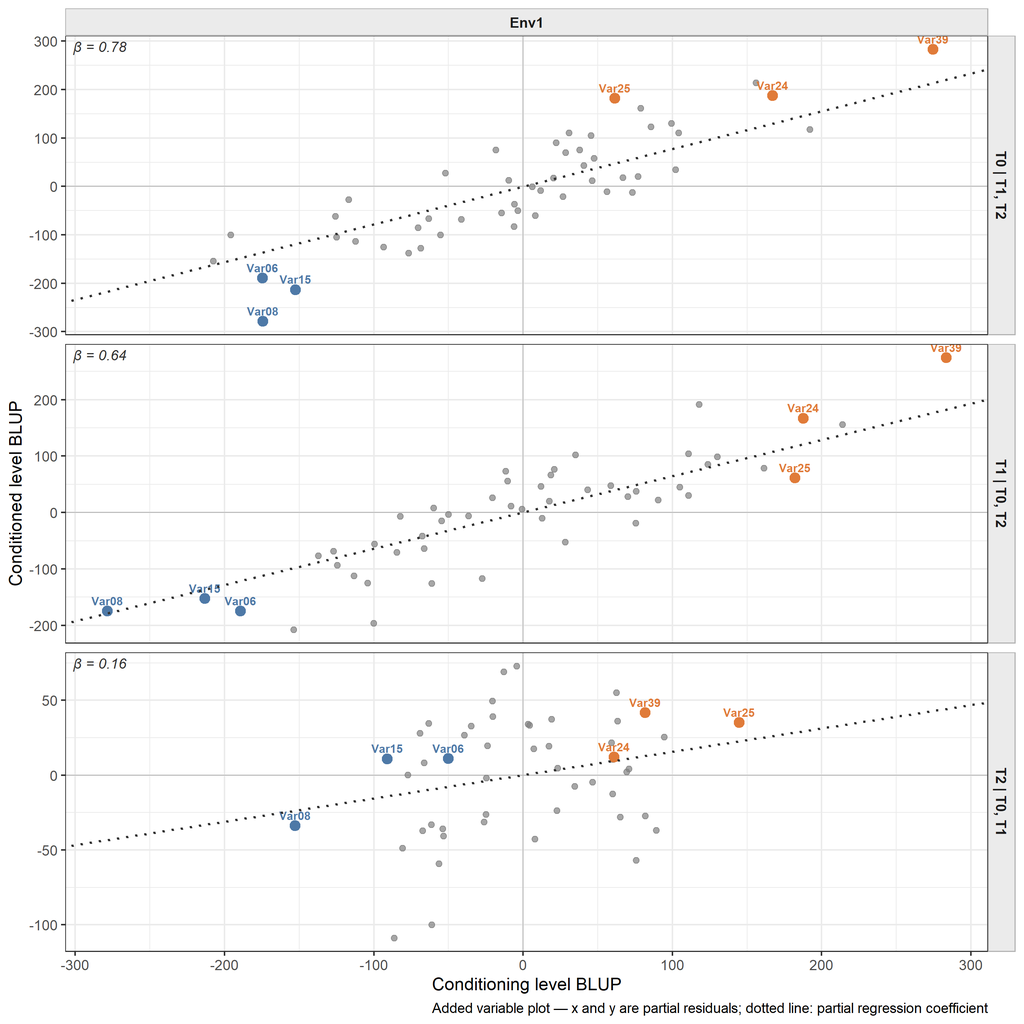

```r
# Slice 1: first conditioning treatment on x (T1 for T0; T0 for T1 and T2)
p_reg1 <- plot_randomRegress(res1, type = "regress")
print(p_reg1)
```

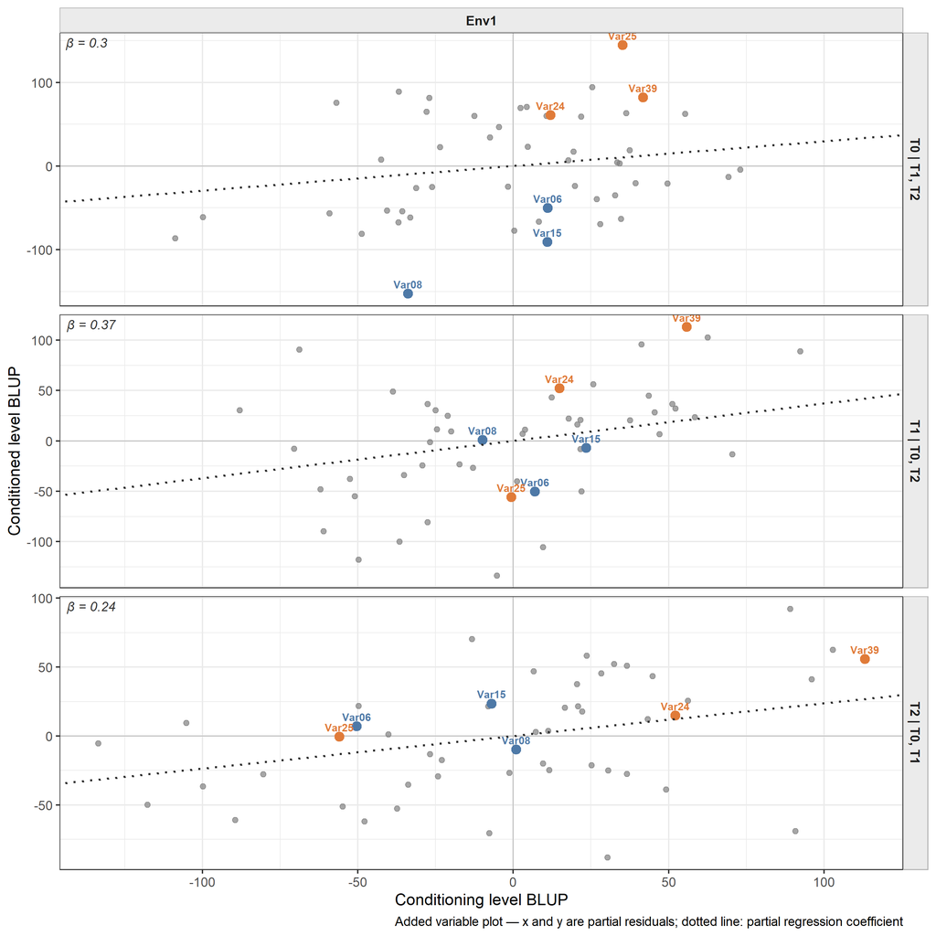

```r
# Slice 2: second conditioning treatment on x (T2 for T0 and T1; T1 for T2)
p_reg1_cx <- plot_randomRegress(res1, type = "regress", cond_x = 2L)
print(p_reg1_cx)
```

Comparing the slopes across the two slices reveals the relative contribution of each conditioning treatment to explaining the conditioned treatment’s BLUPs. A steeper slope in one slice than the other indicates that dimension of $A_j$ carries more of the shared genetic signal.

### Quadrant plot with default highlights

The quadrant plot places the T0 BLUPs on the x-axis and **adjusted** on the y-axis. Under partial conditioning, every treatment has an adjusted axis, so there are three quadrant panels:

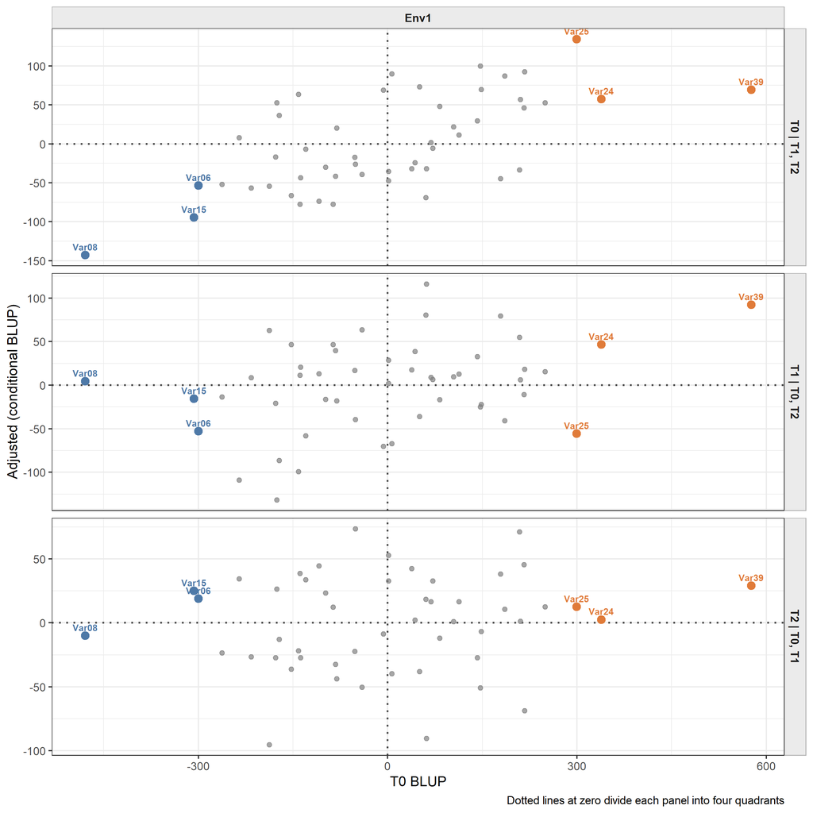

```r
p_quad1 <- plot_randomRegress(res1, type = "quadrant", highlight = "default")
print(p_quad1)
```

The default highlight algorithm (`highlight = "default"`) selects up to six varieties to annotate across all panels — up to three from the top-right quadrant (high baseline + high adjusted, shown in orange) and up to three from the bottom-left (low baseline + low adjusted, shown in blue). Within each quadrant the candidates are restricted to varieties whose distance from the origin exceeds the within-quadrant median, and the final selection is simply the most extreme of those candidates, ordered by decreasing distance from the origin. The same varieties are labelled in every site and treatment-pair panel, making it easy to trace how a variety’s relative position shifts across panels.

Varieties that appear in the top-right of all panels respond positively to every treatment; those that shift between quadrants across panels show treatment-specific responses. To highlight specific varieties instead, pass a character vector of variety names, e.g. `highlight = c("Var01", "Var15", "Var22")`; to suppress highlighting entirely, use `highlight = NULL`.

## Example 2 — Multi-site, factor analytic model

### Simulated data

We now scale to a multi-environment setting: 40 varieties, 4 sites, and the same three nitrogen treatments. The FA(2) model is the standard choice for MET analyses — it captures the dominant axes of genotype × environment interaction parsimoniously.

```r
out2 <- simTrialData(
  nvar       = 40L,
  nsite      = 4L,
  treatments = c("T0", "T1", "T2"),
  nrep       = 3L,
  seed       = 42L,
  verbose    = FALSE
)
dat2 <- out2$data
```

The `"blup"` plot of `plot_simTrialData()` visualises the true genetic values across all 12 treatment × site groups, revealing the GEI structure baked into the simulation:

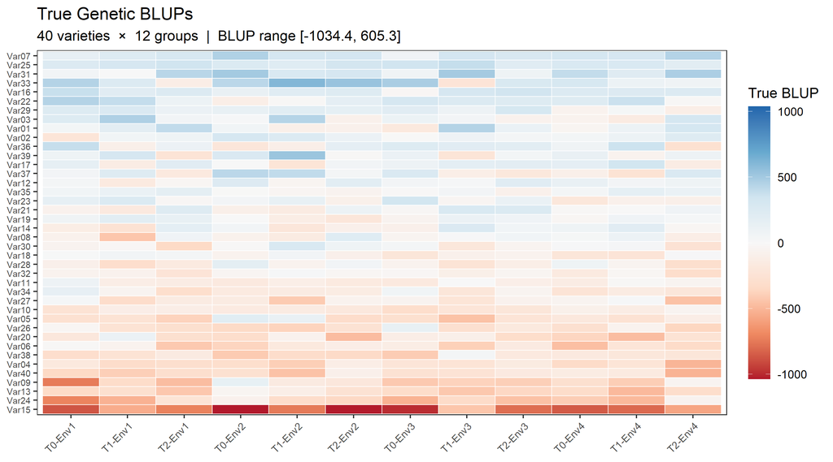

```r
plot_simTrialData(out2, type = "blup", sort = TRUE)
```

Varieties cluster into those with broadly positive responses across all treatment × site groups (top rows) and those with more variable or treatment-specific patterns — exactly the structure that `randomRegress()` is designed to unpack.

### Forming `TSite` and fitting the FA(2) model

```r
dat2$TSite  <- interaction(dat2$Treatment, dat2$Site, sep = "-")
dat2$Row    <- factor(dat2$Row)
dat2$Column <- factor(dat2$Column)
levs2       <- c("T0", "T1", "T2")
```

A **factor analytic** model with 2 factors provides a parsimonious description of the $12 \times 12$ G-matrix across 4 sites and 3 treatments. The two factors capture the dominant axes of genetic co-variation — typically a general adaptation factor and a GEI factor:

```r
model2 <- asreml(
  yield    ~ TSite,
  random   = ~ fa(TSite, 2):Variety + at(Site):Rep,
  residual = ~ dsum(~ ar1(Row):ar1(Column) | Site),
  data     = dat2,
  maxit    = 30L
)
model2 <- update(model2)
```

```r
vc2 <- summary(model2)$varcomp
vc2[grepl("TSite", rownames(vc2)), ]
```

```
                                   component   std.error    z.ratio bound %ch
fa(TSite, 2):Variety!T0-Env1!var     0.00000          NA         NA     F  NA
fa(TSite, 2):Variety!T1-Env1!var 31169.32349 18120.25787  1.7201369     P 0.0
fa(TSite, 2):Variety!T2-Env1!var     0.00000          NA         NA     F  NA
fa(TSite, 2):Variety!T0-Env2!var 54926.68936 24527.13836  2.2394251     P 0.0
fa(TSite, 2):Variety!T1-Env2!var 22868.11521 17109.05408  1.3366090     P 0.1
fa(TSite, 2):Variety!T2-Env2!var 16089.26486 15473.96030  1.0397639     P 0.1
fa(TSite, 2):Variety!T0-Env3!var  2999.29923 15815.76079  0.1896399     P 1.2
fa(TSite, 2):Variety!T1-Env3!var     0.00000          NA         NA     F  NA
fa(TSite, 2):Variety!T2-Env3!var 14017.49345 15189.67375  0.9228304     P 0.2
fa(TSite, 2):Variety!T0-Env4!var 15412.66286 15742.11898  0.9790717     P 0.1
fa(TSite, 2):Variety!T1-Env4!var 52730.42248 24332.96004  2.1670369     P 0.0
fa(TSite, 2):Variety!T2-Env4!var 14105.16152 16691.31389  0.8450600     P 0.4
fa(TSite, 2):Variety!T0-Env1!fa1   296.52970    48.50413  6.1134933     P 0.0
fa(TSite, 2):Variety!T1-Env1!fa1   157.99867    51.56553  3.0640364     P 0.1
fa(TSite, 2):Variety!T2-Env1!fa1   130.69863    54.17348  2.4125946     P 0.0
fa(TSite, 2):Variety!T0-Env2!fa1   230.96691    62.88517  3.6728360     P 0.1
fa(TSite, 2):Variety!T1-Env2!fa1   219.51770    50.73434  4.3268073     P 0.0
fa(TSite, 2):Variety!T2-Env2!fa1   205.56883    48.34382  4.2522255     P 0.0
fa(TSite, 2):Variety!T0-Env3!fa1   275.93292    48.09331  5.7374494     P 0.0
fa(TSite, 2):Variety!T1-Env3!fa1   116.83634    60.85912  1.9197838     P 0.1
fa(TSite, 2):Variety!T2-Env3!fa1   257.11803    49.03558  5.2434998     P 0.0
fa(TSite, 2):Variety!T0-Env4!fa1   143.98589    49.50092  2.9087516     P 0.1
fa(TSite, 2):Variety!T1-Env4!fa1   206.09352    61.50308  3.3509463     P 0.0
fa(TSite, 2):Variety!T2-Env4!fa1   119.58963    54.90667  2.1780528     P 0.1
fa(TSite, 2):Variety!T0-Env1!fa2     0.00000          NA         NA     F  NA
fa(TSite, 2):Variety!T1-Env1!fa2   -59.58202    57.44751 -1.0371558     P 0.4
fa(TSite, 2):Variety!T2-Env1!fa2  -190.95183    49.58988 -3.8506209     P 0.1
fa(TSite, 2):Variety!T0-Env2!fa2  -120.72768    65.76830 -1.8356515     P 0.3
fa(TSite, 2):Variety!T1-Env2!fa2   -53.10018    55.72059 -0.9529723     P 0.5
fa(TSite, 2):Variety!T2-Env2!fa2   -57.16652    53.43331 -1.0698667     P 0.2
fa(TSite, 2):Variety!T0-Env3!fa2    48.90298    54.13607  0.9033345     P 0.4
fa(TSite, 2):Variety!T1-Env3!fa2  -262.53440    49.08220 -5.3488719     P 0.0
fa(TSite, 2):Variety!T2-Env3!fa2   -33.80408    56.16459 -0.6018754     P 0.0
fa(TSite, 2):Variety!T0-Env4!fa2  -100.80011    50.52813 -1.9949306     P 0.3
fa(TSite, 2):Variety!T1-Env4!fa2  -114.52058    65.29071 -1.7540104     P 0.0
fa(TSite, 2):Variety!T2-Env4!fa2  -173.36675    53.09673 -3.2651116     P 0.2
```

The varcomp rows show the factor loadings (`!fa1`, `!fa2`) and specific variances (`!var`) for each `TSite` level. The G-matrix reconstructed from these is $\hat{\mathbf{G}} = \hat{\boldsymbol{\Lambda}}\hat{\boldsymbol{\Lambda}}^\top + \hat{\boldsymbol{\Psi}}$.

### Running `randomRegress()` — baseline conditioning

For multi-site data with an FA model, **baseline conditioning** is the most widely used scheme: T0 is the baseline (control) treatment, and T1 and T2 are conditioned on T0 to give treatment-specific adjusted BLUPs.

```r
res2 <- randomRegress(
  model2,
  term = "fa(TSite, 2):Variety",
  levs = levs2,
  type = "baseline",
  sep  = "-"
)
```

With 4 sites, `beta` has 4 rows (one per site) and `sigmat` has 4 rows. The site-specific regression slopes in `beta` capture how the treatment response relationship changes across environments:

```r
# Site-specific regression coefficients for T1 conditioned on T0
round(res2$beta$T1, 3)
```

```
        T0
Env1 0.533
Env2 0.465
Env3 0.238
Env4 0.890
```

### Regression plot

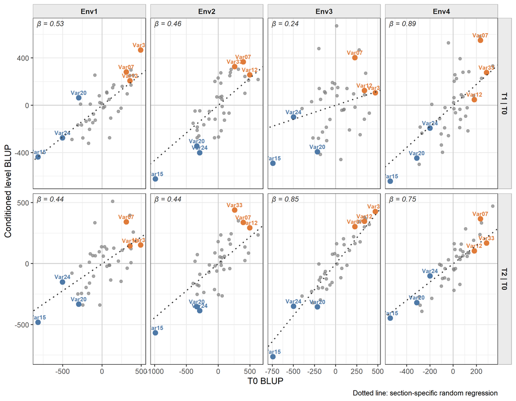

```r
p_reg2 <- plot_randomRegress(res2, type = "regress")
print(p_reg2)
```

Each panel corresponds to one site × treatment pair. The dotted regression line through the origin carries the site-specific $\hat{\beta}$ slope. Panels where $\hat{\beta}$ differs substantially across sites indicate heterogeneous treatment responses — the G-matrix captures this as off-diagonal structure between treatment × site combinations.

### Quadrant plot — default highlights

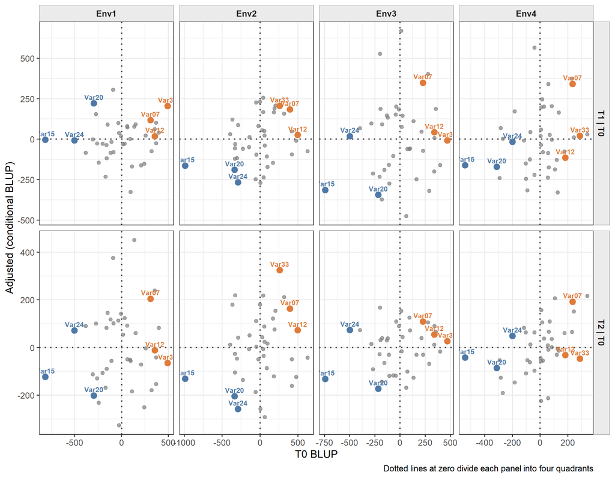

```r
p_quad2 <- plot_randomRegress(res2, type = "quadrant", highlight = "default")
print(p_quad2)
```

The automatic highlight algorithm identifies the six most informative archetypes by their position in the baseline–adjusted space, averaged across all sites. Orange points are top-right archetypes (broadly adapted and responsive); blue points are bottom-left archetypes (consistently poor performers). The same six varieties are labelled in every panel.

### Filtering to a single treatment pair

For multi-site multi-treatment results, `treatments` restricts which panels are shown. This is useful when a particular treatment comparison is of primary interest:

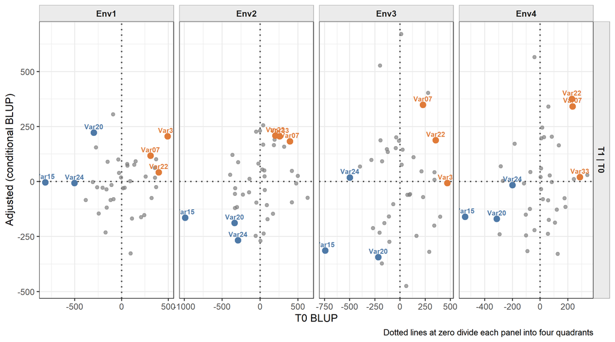

```r
p_t1 <- plot_randomRegress(res2, type = "quadrant",
                            treatments = "T1", highlight = "default")
print(p_t1)
```

### G-matrix heatmap

The $12 \times 12$ G-matrix correlation heatmap reveals the full structure of genetic co-variation across all treatment × site combinations:

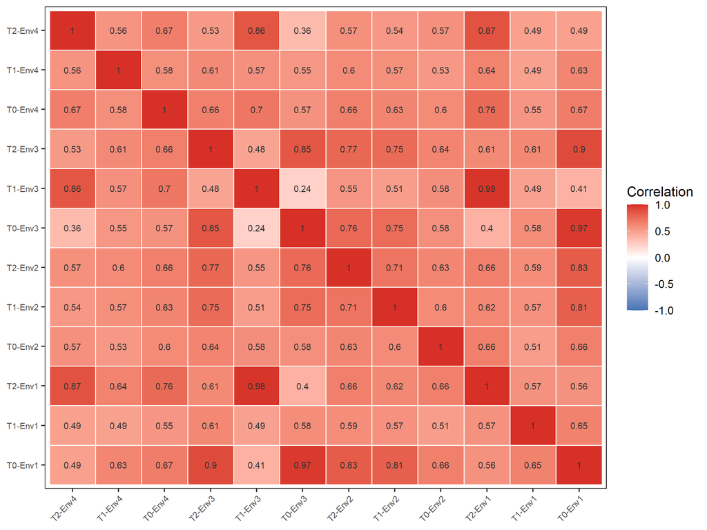

```r
p_gmat2 <- plot_randomRegress(res2, type = "gmat")
print(p_gmat2)
```

### Bespoke visualisation with `return_data = TRUE`

All three plot types support `return_data = TRUE`, which returns the tidy data frame used to build the plot. This enables custom `ggplot2` visualisations beyond the built-in types.

The first two columns identify the row and carry the same names as `res$blups`: `Section` for the section label, and the unit factor named as `term` names it — `Variety` here, but `Genotype` for a term of `us(TSite):Genotype`. Read the two names from `res$section` and `res$unit` rather than hard-coding them:

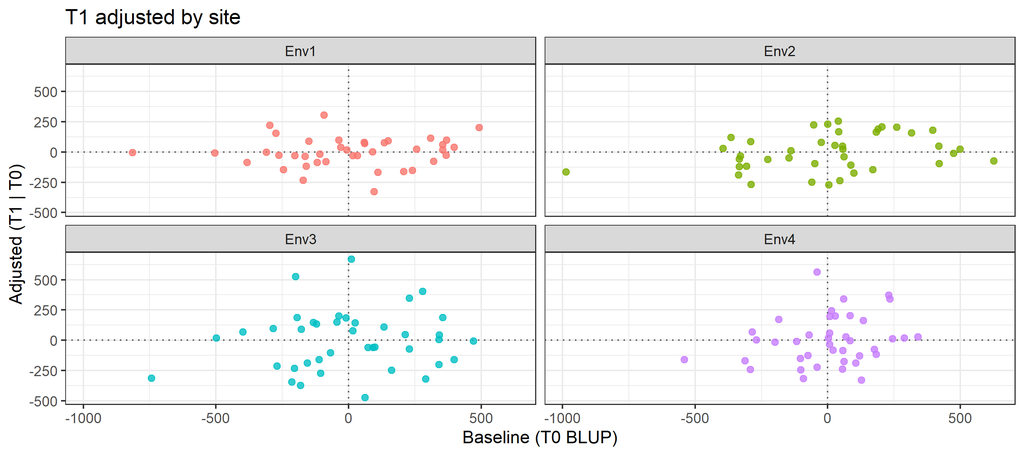

```r
df_t1 <- plot_randomRegress(res2, type = "quadrant",
                             treatments  = "T1",
                             return_data = TRUE)

ggplot(df_t1, aes(x = x, y = y, colour = Section)) +
  geom_hline(yintercept = 0, linetype = "dotted", colour = "grey40") +
  geom_vline(xintercept = 0, linetype = "dotted", colour = "grey40") +
  geom_point(size = 1.8, alpha = 0.8) +
  facet_wrap(~ Section, nrow = 2L) +
  labs(x = "Baseline (T0 BLUP)",
       y = "Adjusted (T1 | T0)",
       title = "T1 adjusted by site") +
  theme_bw() +
  theme(legend.position = "none")
```

## Summary

### `randomRegress()`

| Task | Code |
| --- | --- |
| Baseline conditioning | `type = "baseline"` (default) |
| Fully orthogonal (Gram-Schmidt) | `type = "sequential"` |
| Partial genetic variances | `type = "partial"` |
| Bespoke conditioning | `type = "custom", cond = list(...)` |
| Single site, corgh term | `term = "corgh(TSite):Variety"` |
| Multi-site, FA term | `term = "fa(TSite, 2):Variety"` |
| Genomic relationship matrix | `term = "us(TSite):vm(Variety, giv1)"` |

### `plot_randomRegress()`

| Task | Code |
| --- | --- |
| Regression scatter plot | `plot_randomRegress(res, type = "regress")` |
| Baseline–adjusted plot | `plot_randomRegress(res, type = "quadrant")` |
| G-matrix heatmap | `plot_randomRegress(res, type = "gmat")` |
| Default highlights | `highlight = "default"` |
| Named variety highlights | `highlight = c("Var01", "Var15")` |
| Suppress highlights | `highlight = NULL` |
| Restrict treatment panels | `treatments = "T1"` |
| Select x-axis conditioning treatment | `cond_x = 2L` |
| Export plot data | `return_data = TRUE` |
| Absolute yield scale | `centre = TRUE` |

## References

Lemerle, D., Smith, A., Verbeek, B., Koetz, E., Lockley, P. & Martin, P. (2006). Incremental crop tolerance to weeds: A measure for selecting competitive ability in Australian wheats. *Euphytica*, **149**, 85–95. https://doi.org/10.1007/s10681-005-9056-5

McDonald G, Bovill W, Taylor J, Wheeler R. (2015) Responses to phosphorus among wheat genotypes. *Crop and Pasture Science*, **66**(5), 430–444. https://doi.org/10.1071/CP14191